# Coursework Report

*N* removed NAs: 5

*N* removed <18: 30

**Correct typo age:** 24

*N* total clean: 133

| Group | *N* | *M*<sub>age</sub> | % green |
| --- | --- | --- | --- |
| Control | 64 | 20.25 | 51.04 |
| Experim | 69 | 20.99 | 42.03 |

| Gender | *N* | *M*<sub>age</sub> | % green |
| --- | --- | --- | --- |
| Male | 71 | 20.58 | 46.48 |
| Female | 43 | 21.07 | 49.61 |
| Other | 19 | 19.84 | 38.60 |

**Main analysis results**

**cleaner:**  
χ<sup>2</sup>(1) = 1.63, *p* = .202

**dishwasher:**  
χ<sup>2</sup>(1) = 0, *p* = .970

[interactive chart not shown]

[figure not shown]

[interactive chart not shown]

# Coursework Report

Analysing Data, Spring 2020

```
## [1] 15
```

```
## [1] 489
```

```
## tibble [489 x 6] (S3: tbl_df/tbl/data.frame)
##  $ ID       : Factor w/ 168 levels "ABUA","ACBK",..: 128 128 128 117 117 117 42 42 42 91 ...
##  $ AGE      : num [1:489] 21 21 21 24 24 24 23 23 23 23 ...
##  $ GENDER   : Factor w/ 3 levels "male","female",..: 2 2 2 1 1 1 3 3 3 2 ...
##  $ CONDITION: Factor w/ 3 levels "control","experimental",..: 2 2 2 2 2 2 2 2 2 2 ...
##  $ PRODUCT  : Factor w/ 3 levels "dishwasher","cleaner",..: 1 2 3 1 2 3 1 2 3 1 ...
##  $ CHOICE   : Factor w/ 2 levels "luxury","green": 2 1 1 1 1 1 2 1 1 2 ...
##  - attr(*, "na.action")= 'omit' Named int [1:15] 1 2 3 61 62 63 217 218 219 310 ...
##   ..- attr(*, "names")= chr [1:15] "1" "2" "3" "61" ...
```

```
## # A tibble: 6 x 6
## # Groups:   GENDER [3]
##   GENDER CONDITION          n  perc mean_age sd_age
##   <fct>  <fct>          <int> <dbl>    <dbl>  <dbl>
## 1 male   status neutral   111 27.9      20.1   2.11
## 2 male   high status      102 25.6      21.1   2.25
## 3 female status neutral    57 14.3      21.1   2.06
## 4 female high status       71 17.8      21.0   1.82
## 5 other  status neutral    24  6.03     19     1.02
## 6 other  high status       33  8.29     20.5   2.00
```

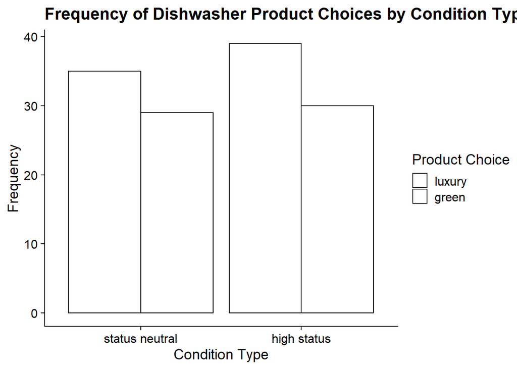

```
##
##                  luxury green
##   status neutral     35    29
##   high status        39    30
```

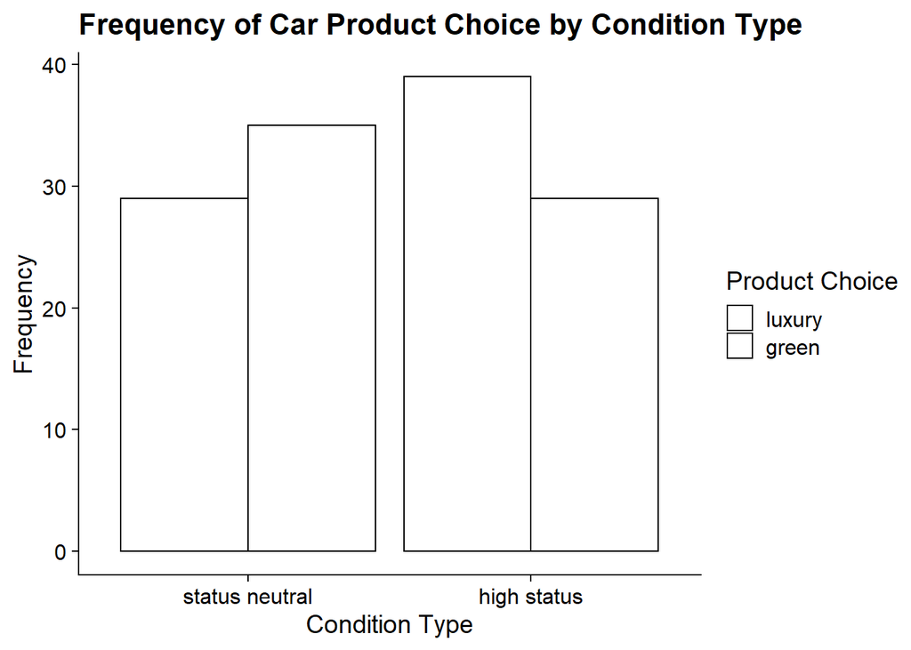

```
##
##                  luxury green
##   status neutral     29    35
##   high status        39    29
```

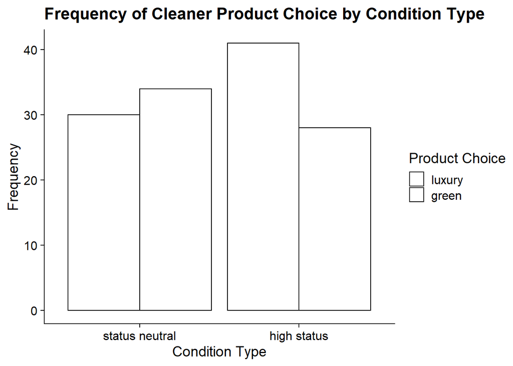

```
##
##                  luxury green
##   status neutral     30    34
##   high status        41    28
```

```
##
##  Pearson's Chi-squared test with Yates' continuity correction
##
## data:  d
## X-squared = 0.0014504, df = 1, p-value = 0.9696
```

```
##
##  Pearson's Chi-squared test with Yates' continuity correction
##
## data:  cl
## X-squared = 1.626, df = 1, p-value = 0.2023
```

```
##
##  Pearson's Chi-squared test with Yates' continuity correction
##
## data:  ca
## X-squared = 1.4619, df = 1, p-value = 0.2266
```

[output not shown]

## # A tibble: 6 x 6

## # Groups: GENDER [3]

## GENDER CONDITION n perc mean_age sd_age

## 1 male status neutral 111 27.9 20.1 2.11

## 2 male high status 102 25.6 21.1 2.25

## 3 female status neutral 57 14.3 21.1 2.06

## 4 female high status 71 17.8 21.0 1.82

## 5 other status neutral 24 6.03 19 1.02

## 6 other high status 33 8.29 20.5 2.00

[output not shown]

## status neutral 35 29

## high status 39 30

[output not shown]

## status neutral 29 35

## high status 39 29

[output not shown]

## status neutral 30 34

## high status 41 28

[output not shown]

## Pearson’s Chi-squared test with Yates’ continuity correction

## data: d

## X-squared = 0.0014504, df = 1, p-value = 0.9696

[output not shown]

## Pearson’s Chi-squared test with Yates’ continuity correction

## data: ca

## X-squared = 1.4619, df = 1, p-value = 0.2266

[output not shown]

## Pearson’s Chi-squared test with Yates’ continuity correction

## data: cl

## X-squared = 1.626, df = 1, p-value = 0.2023

[output not shown]

# Discussion

To summarise the results of this research, it is clear that initiating status motives within individuals does not increase their likeliness to buy enviornmentally friendly products over non-environmentally friendly luxury product. This is clearly portrayed in the data, showing that in the high-status story condition, for all of the three tested products (dishwasher, cleaner and car), the luxury option of them was chosen over the green product by the majority.

Within the original study by Griskevicius et al in 2010, the researchers found that by activating status motives within individuals, it led them to chose basic green products over luxurious non-green products, and concluded that status motives can lead to competition which can in turn cause an increase in pro-enviornmental behaviour within society. In comparison to this, the results of our study is very contradictory as our data has shown that initating status motives within the sample did not increase choosing of green products over luxurious ones. For this theory that we are investigating, results like do not produce positivity answers, as there is still contradictory evidence being found, not making it clear whether this theory is something that may be a fluke or is a phenomenon that is actually worth investigating.

Additionally, when looking at other reseach within the same area, both supporting evidence and contradictory evidence can be found. Basil and Webber (2006), found that individuals are driven more to purchase “green” products if they come along with label or a positive trait, which can be seen as status motives. In addition, when similar studies were conducted with organic coffee being used as the pro-green product, corresponding results were discovered where the frequency of individuals selecting the organic coffee over the normal coffee was significantly higher when in a public setting, over a private one (Aagerup & Nilsson, 2016). These pieces of research contradict the results that we have found within our study, however, there is another study conducted by Dietz, Ostrom and Stern (2003), which suggests that though environmentally friendly and sustainable products are now vastly available, humans are reluctant to change familiar patterns of behaviour, as making the change from non-green products to green products, often includes personal sacrifice, due to having to pay more for something that is usually of a lower quality. This piece of research supports our research and corresponds well with the results of our study, also giving a suggestion as to why people were not motivated to buy green when status motives were activated.

In conclusion, our results did not correspond with the operational hypothesis and initiating status motives did not encourage choosing green products over luxurious, non-green ones. Many other pieces of research have found that status motives do encourage green buying, which we did not find. More research could be conducted to collect even more data for this theory, for example, seeing if buying green is encourage by status motives, specifically, from being in public.

# References

1. Aagerup, U., & Nilsson, J. (n.d.). Green consumer behaviour: Being good or seeming good? 25(3), 274–284. https://doi.org/10.1108/jpbm-06-2015-0903
2. Basil, D.Z. and Weber, D. (2006), “Values motivation and concern for appearances: the effect of personality traits on responses to corporate social responsibility”, International Journal of Nonprofit & Voluntary Sector Marketing, Vol. 11 No. 1, pp. 61-72.
3. Dietz, T., Ostrom, E., & Stern, P. C. (2003). The Struggle to Govern the Commons. Urban Ecology, 302(5652), 611–622. doi: 10.1007/978
4. Griskevicius, V. (2008). Conspicuous conservation: Pro-environmental consumption and status competition. ProQuest Dissertations Publishing.